# Using figsimR: Diagnosing the Variation Gap and Dissecting Community Assembly

Yiyi Dong

2025-08-14

# 1. Introduction: When theory meets variability

Ecologists have long recognized that natural communities exhibit large variability. `figsimR` operationalizes a mechanistic null workflow: we calibrate a Full Intrinsic Model (FIM) to reproduce empirical means, then quantify the Variation Gap—the residual dispersion that not captured by the current FIM configuration. Finally, we use mechanism knockout experiments to dissect which internal processes maintain the theoretical structure.

This vignette shows the full workflow on a fig–wasp case study, with small defaults for speed. For the full reproduction (long runs), see the package website article “Reproducing the case study” (or run this vignette with `RUN_HEAVY <- TRUE`).

Framing & scope. In this vignette, the “Variation Gap” is defined strictly as model–data residual variation under the current FIM configuration. It is not a claim that ecological variability is inherently “extrinsic” or unknowable. Many well-studied drivers—e.g., environmental/landscape heterogeneity, dispersal, demographic/environmental stochasticity, evolutionary change—can be added as explicit modules and may reduce or eliminate the gap. Here we hold these out of scope to (i) delineate the explanatory envelope of intrinsic mechanisms, and (ii) provide a transparent baseline for subsequent extensions.

# 2. Data and quick look

We use an empirical dataset of fig wasp communities collected from *Ficus racemosa*. Each column is a species’ abundance; each row is one fig (community unit).

```r
# Example data shipped with the package
data(observed_data)          # 935 x 6 abundance matrix (one row per fig)
data(parameter_list_default) # Named lists of biological parameters
data(species_list)           # Character vector of the six focal species

# Inspect the first rows
head(observed_data)
```

```
#>   Ceratosolen_sp Sycophaga_testacea Apocrypta_sp Sycophaga_mayri
#> 1           1163                  3            0               2
#> 2           1510                109            2              70
#> 3            744                102            0              39
#> 4           1494                  9            0               8
#> 5           1224                 10            0              42
#> 6            478                 77            1              97
#>   Sycophaga_agraensis Apocrypta_westwoodi
#> 1                  32                 189
#> 2                  22                  45
#> 3                  62                  12
#> 4                  54                  72
#> 5                  14                 103
#> 6                  39                  32
```

**Provenance.** Aung, K. M., Chen, H. H., Segar, S. T., Miao, B. G., Peng, Y. Q., & Liu, C. (2022). *Journal of Animal Ecology*, 91, 1303–1315. https://doi.org/10.1111/1365-2656.13701 * **Background consensus.** The field has long developed rich frameworks for environmental heterogeneity, coexistence, and spatial processes. Our contribution here is procedural: to define a transparent baseline workflow that first saturates intrinsic structure, then diagnoses what remains to be explained.

# 3. Act I — Build the theoretical world (FIM)

## 3.1 Bootstrap empirical metrics (fast)

We summarize alpha, beta, and simple network metrics by bootstrapping figs. Defaults are small to keep this vignette snappy.

```r
obs_metrics <- resample_observed_all_metrics(
  observed_df = observed_data,
  wasp_cols   = species_list,
  n_draws     = 50,     # small for vignette
  sample_n    = 100,    # small for vignette
  seed        = 42,
  calc_func   = calc_all_metrics
)

head(obs_metrics)
```

```
#>   mean_richness mean_shannon mean_simpson mean_evenness mean_bray_curtis
#> 1          4.72    0.8451270    0.4400507     0.5604452        0.6394628
#> 2          4.63    0.7267044    0.3950370     0.4769114        0.6445642
#> 3          4.97    0.8141998    0.4152506     0.5199287        0.6319204
#> 4          4.67    0.7984203    0.4222323     0.5282758        0.6739707
#> 5          4.79    0.7858634    0.4123213     0.5048318        0.6155320
#> 6          4.77    0.7073571    0.3746745     0.4592382        0.6069186
#>   mean_jaccard nestedness connectance links_per_species modularity   source
#> 1    0.3216397   30.65230   0.7866667          43.01483 0.07568093 Observed
#> 2    0.3298794   35.33140   0.7874150          42.07127 0.07018505 Observed
#> 3    0.2815758   39.21992   0.8283333          44.69819 0.05185843 Observed
#> 4    0.3350855   28.26306   0.7861953          42.22912 0.07815846 Observed
#> 5    0.3005463   36.39231   0.8063973          43.43424 0.07015311 Observed
#> 6    0.3035938   33.97170   0.8030303          43.29769 0.07161944 Observed
```

```r
# Summary statistics across all bootstrap replicates
summary(obs_metrics)
```

```
#>  mean_richness    mean_shannon     mean_simpson    mean_evenness
#>  Min.   :4.630   Min.   :0.7074   Min.   :0.3727   Min.   :0.4592
#>  1st Qu.:4.723   1st Qu.:0.7738   1st Qu.:0.4023   1st Qu.:0.4969
#>  Median :4.830   Median :0.7984   Median :0.4193   Median :0.5153
#>  Mean   :4.827   Mean   :0.7999   Mean   :0.4193   Mean   :0.5154
#>  3rd Qu.:4.918   3rd Qu.:0.8235   3rd Qu.:0.4341   3rd Qu.:0.5323
#>  Max.   :5.060   Max.   :0.8889   Max.   :0.4556   Max.   :0.5604
#>  mean_bray_curtis  mean_jaccard      nestedness     connectance
#>  Min.   :0.5916   Min.   :0.2499   Min.   :28.26   Min.   :0.7817
#>  1st Qu.:0.6163   1st Qu.:0.2802   1st Qu.:33.00   1st Qu.:0.7980
#>  Median :0.6283   Median :0.3008   Median :34.90   Median :0.8099
#>  Mean   :0.6310   Mean   :0.2980   Mean   :34.81   Mean   :0.8108
#>  3rd Qu.:0.6427   3rd Qu.:0.3168   3rd Qu.:37.06   3rd Qu.:0.8266
#>  Max.   :0.6798   Max.   :0.3351   Max.   :41.03   Max.   :0.8433
#>  links_per_species   modularity         source
#>  Min.   :42.07     Min.   :0.03925   Length:50
#>  1st Qu.:42.88     1st Qu.:0.05316   Class :character
#>  Median :43.58     Median :0.06054   Mode  :character
#>  Mean   :43.65     Mean   :0.06102
#>  3rd Qu.:44.40     3rd Qu.:0.06944
#>  Max.   :45.60     Max.   :0.08468
```

```r
# Optionally extract a cleaner subset of core diversity/network metrics
obs_metrics_mean <- obs_metrics[, 1:10]
```

## 3.2 Parameter ranges for FIM calibration

We convert a parameter list into ranges for Latin hypercube exploration. We remove fixed items (interaction matrix/weight).

```r
# Prepare parameter ranges for model resampling or optimization
new_param_ranges <- parameter_list_default

# Remove entries not relevant for optimization (e.g., fixed interaction matrix)
new_param_ranges[c("interaction_matrix", "interaction_weight")] <- NULL

# Convert the cleaned parameter list into a structured format suitable for optimization
# This typically standardizes into a list of vectors/ranges for each parameter
new_param_ranges <- convert_parameter_list_to_param_ranges(new_param_ranges)

# Check the resulting structure of the parameter ranges
str(new_param_ranges)
```

```
#> List of 60
#>  $ entry_mu_Sycophaga_testacea                         : num [1:2] 4.2 7.8
#>  $ entry_size_Sycophaga_testacea                       : num [1:2] 6.3 11.7
#>  $ fecundity_mean_Sycophaga_testacea                   : num [1:2] 15.4 28.6
#>  $ fecundity_dispersion_Sycophaga_testacea             : num [1:2] 1.05 1.95
#>  $ egg_success_prob_Sycophaga_testacea                 : num [1:2] 0.56 1
#>  $ layer_core_raw_Sycophaga_testacea                   : num [1:2] 0.49 0.91
#>  $ layer_mid_raw_Sycophaga_testacea                    : num [1:2] 0.175 0.325
#>  $ layer_outer_raw_Sycophaga_testacea                  : num [1:2] 0.035 0.065
#>  $ entry_mu_Apocrypta_sp                               : num [1:2] 7 13
#>  $ entry_size_Apocrypta_sp                             : num [1:2] 5.6 10.4
#>  $ fecundity_mean_Apocrypta_sp                         : num [1:2] 2.8 5.2
#>  $ fecundity_dispersion_Apocrypta_sp                   : num [1:2] 1.54 2.86
#>  $ egg_success_prob_Apocrypta_sp                       : num [1:2] 0.42 0.78
#>  $ layer_core_raw_Apocrypta_sp                         : num [1:2] 0.035 0.065
```

[output cut: 46 more lines]

```r
# To avoid long computation time during review (~1 hour), a precomputed optimization result file
# (`lhs_optimize_result.rds`) is provided. If this file is present in the working directory, it
# will be loaded automatically.
#
# If you prefer to re-run the full Latin Hypercube Sampling optimization yourself, you may comment
# out the conditional block below and run `explore_parameter_space_lhs()` directly.

# Load required libraries for parallel computing and progress tracking
#library(future)      # for parallel backend
#library(progressr)   # to display progress bar during long computation

# Set up global progress bar handler and seed for reproducibility
safe_handlers(global = TRUE)
safe_handlers("txtprogressbar")  # show text progress bar in console
set.seed(42)

# Load precomputed result if available; otherwise run the full optimization (may take ~1 hour), we run small dataset for testing
if (file.exists("lhs_optimize_result.rds")) {
  message("Loading precomputed LHS optimization result...")
  lhs_optimize_result <- readRDS("lhs_optimize_result.rds")
} else {
  message("Running LHS optimization from scratch (this may take ~1 hour)...")
  lhs_optimize_result <- explore_parameter_space_lhs(
    new_param_ranges = new_param_ranges,                  # parameter ranges to explore
    observed_summary = obs_metrics_mean,                  # summary statistics from observed data
    num_figs = 200,                                      # number of figs to simulate per run
    n_draws = 50,                                        # bootstrap iterations for metric calculation
    sample_n = 20,                                       # number of figs drawn per bootstrap sample
    n_samples = 50,                                      # total number of parameter combinations to test
    wasp_cols = species_list,                             # columns to evaluate in diversity metrics
    n_cores = 4,                                          # number of CPU cores to use in parallel
    parameter_list_template = parameter_list_default      # base parameter list structure
  )
}


# Extract the single best-performing parameter row (minimum loss)
best_lhs_optimize_result <- lhs_optimize_result[1, ]
print(best_lhs_optimize_result)
```

```
#>   entry_mu_Sycophaga_testacea entry_size_Sycophaga_testacea
#> 1                    6.667713                      10.82997
#>   fecundity_mean_Sycophaga_testacea fecundity_dispersion_Sycophaga_testacea
#> 1                          19.74174                                1.185752
#>   egg_success_prob_Sycophaga_testacea layer_core_raw_Sycophaga_testacea
#> 1                           0.8518234                         0.8066216
#>   layer_mid_raw_Sycophaga_testacea layer_outer_raw_Sycophaga_testacea
#> 1                        0.2703918                         0.05226415
#>   entry_mu_Apocrypta_sp entry_size_Apocrypta_sp fecundity_mean_Apocrypta_sp
#> 1              11.22559                7.635546                    4.558396
#>   fecundity_dispersion_Apocrypta_sp egg_success_prob_Apocrypta_sp
#> 1                          2.167291                     0.5410174
#>   layer_core_raw_Apocrypta_sp layer_mid_raw_Apocrypta_sp
#> 1                  0.06189735                  0.1253423
#>   layer_outer_raw_Apocrypta_sp parasitism_prob_Apocrypta_sp
#> 1                    0.7025789                    0.9177593
#>   entry_mu_Sycophaga_mayri entry_size_Sycophaga_mayri
#> 1                 8.687717                   11.26989
#>   fecundity_mean_Sycophaga_mayri fecundity_dispersion_Sycophaga_mayri
#> 1                       27.15218                             1.942636
#>   egg_success_prob_Sycophaga_mayri layer_core_raw_Sycophaga_mayri
#> 1                        0.6757175                      0.4428865
#>   layer_mid_raw_Sycophaga_mayri layer_outer_raw_Sycophaga_mayri
#> 1                     0.2860505                      0.01849057
#>   entry_mu_Ceratosolen_sp entry_size_Ceratosolen_sp
#> 1                15.67823                  9.134708
#>   fecundity_mean_Ceratosolen_sp fecundity_dispersion_Ceratosolen_sp
#> 1                      101.8401                             0.71548
#>   egg_success_prob_Ceratosolen_sp layer_core_raw_Ceratosolen_sp
#> 1                       0.9125306                     0.5875853
#>   layer_mid_raw_Ceratosolen_sp layer_outer_raw_Ceratosolen_sp
#> 1                    0.1211348                     0.01245194
#>   entry_mu_Sycophaga_agraensis entry_size_Sycophaga_agraensis
#> 1                      6.19006                        8.35172
#>   fecundity_mean_Sycophaga_agraensis fecundity_dispersion_Sycophaga_agraensis
#> 1                           3.751226                                 1.245152
#>   egg_success_prob_Sycophaga_agraensis layer_core_raw_Sycophaga_agraensis
#> 1                            0.4839784                         0.01204476
#>   layer_mid_raw_Sycophaga_agraensis layer_outer_raw_Sycophaga_agraensis
#> 1                         0.3981299                           0.4271367
```

[output cut: 13 more lines]

```
#> 1                                     0.2979182
#>   egg_success_prob_by_phase_Apocrypta_westwoodi_phase2
#> 1                                            0.1205751
#>   egg_success_prob_by_phase_Apocrypta_westwoodi_phase3
#> 1                                            0.8122677
#>   egg_success_prob_by_phase_Sycophaga_agraensis_phase2
#> 1                                             0.103624
#>   egg_success_prob_by_phase_Sycophaga_agraensis_phase3
#> 1                                            0.9736815
#>   egg_success_prob_by_phase_Sycophaga_mayri_phase2
#> 1                                        0.9318904
#>   egg_success_prob_by_phase_Ceratosolen_sp_phase2
#> 1                                       0.9795987
#>   egg_success_prob_by_phase_Sycophaga_testacea_phase1  loss
#> 1                                           0.9210296 1e+06
```

```r
#saveRDS(lhs_optimize_result, file = "lhs_optimize_result.rds")

# Rebuild the full parameter list object from the best result row
# This list will be used in subsequent simulations
lhs_best_param_list <- rebuild_parameter_list_from_row(
  best_lhs_optimize_result,
  parameter_list_default
)

# Display the reconstructed best-fit parameter list
lhs_best_param_list
```

```
#> $entry_mu
#>  Sycophaga_testacea        Apocrypta_sp     Sycophaga_mayri      Ceratosolen_sp
#>            6.667713           11.225595            8.687717           15.678231
#> Sycophaga_agraensis Apocrypta_westwoodi
#>            6.190060            6.287686
#>
#> $entry_size
#>  Sycophaga_testacea        Apocrypta_sp     Sycophaga_mayri      Ceratosolen_sp
#>           10.829973            7.635546           11.269890            9.134708
#> Sycophaga_agraensis Apocrypta_westwoodi
#>            8.351720            7.038227
#>
#> $fecundity_mean
#>  Sycophaga_testacea        Apocrypta_sp     Sycophaga_mayri      Ceratosolen_sp
#>           19.741740            4.558396           27.152180          101.840103
#> Sycophaga_agraensis Apocrypta_westwoodi
#>            3.751226            3.961712
#>
#> $fecundity_dispersion
#>  Sycophaga_testacea        Apocrypta_sp     Sycophaga_mayri      Ceratosolen_sp
#>           1.1857522           2.1672906           1.9426355           0.7154800
#> Sycophaga_agraensis Apocrypta_westwoodi
#>           1.2451516           0.9873359
#>
#> $egg_success_prob
#>  Sycophaga_testacea        Apocrypta_sp     Sycophaga_mayri      Ceratosolen_sp
#>           0.8518234           0.5410174           0.6757175           0.9125306
#> Sycophaga_agraensis Apocrypta_westwoodi
#>           0.4839784           0.5529394
#>
#> $egg_success_prob_by_phase
#> $egg_success_prob_by_phase$Apocrypta_sp
#>    phase1    phase2
#> 0.4889952 0.2979182
#>
#> $egg_success_prob_by_phase$Apocrypta_westwoodi
#>    phase2    phase3
#> 0.1205751 0.8122677
#>
#> $egg_success_prob_by_phase$Sycophaga_agraensis
```

[output cut: 113 more lines]

```
#>
#> $species_roles$parasitoid$Sycophaga_mayri
#> [1] "Apocrypta_westwoodi"
#>
#> $species_roles$parasitoid$Sycophaga_testacea
#> [1] "Apocrypta_sp"
#>
#> $species_roles$parasitoid$Apocrypta_sp
#> character(0)
#>
#> $species_roles$parasitoid$Apocrypta_westwoodi
#> character(0)
#>
#> $species_roles$parasitoid$Sycophaga_agraensis
#> character(0)
```

## 3.3 Explore parameter space (short demo vs. full)

**Important:** LHS over thousands of samples × 1000‑fig simulations is expensive. In the vignette we either (A) load a precomputed result, or (B) run a tiny demo search. For full runs, set `RUN_HEAVY <- TRUE` and increase `n_samples`, `n_draws`, `sample_n`, and `num_figs`.

```r
# Optional: progress bars (kept OFF in vignette)
# safe_handlers(global = TRUE); safe_handlers("txtprogressbar")

# Try to load a precomputed optimization (ship it in )
lhs_file <- system.file("extdata", "lhs_optimize_result.rds", package = "figsimR")

if (file.exists(lhs_file)) {
  lhs_opt <- readRDS(lhs_file)
} else if (RUN_HEAVY) {
  lhs_opt <- explore_parameter_space_lhs(
    new_param_ranges        = new_param_ranges,
    observed_summary        = obs_metrics[, 1:10], # numeric summary columns
    num_figs                = 1000,
    n_draws                 = 500,
    sample_n                = 200,
    wasp_cols               = species_list,
    parameter_list_template = parameter_list_default,
    n_samples               = 5000,
    top_k                   = 5,
    n_cores                 = max(1, parallel::detectCores() - 1)
  )
} else {
  # Tiny demo search to keep vignette fast; results not scientific
  lhs_opt <- explore_parameter_space_lhs(
    new_param_ranges        = new_param_ranges,
    observed_summary        = obs_metrics[, 1:10],
    num_figs                = 200,
    n_draws                 = 20,
    sample_n                = 100,
    wasp_cols               = species_list,
    parameter_list_template = parameter_list_default,
    n_samples               = 50,    # tiny demo
    top_k                   = 1,
    n_cores                 = 1
  )
}

best_row <- lhs_opt[1, , drop = FALSE]
best_params <- rebuild_parameter_list_from_row(best_row, parameter_list_default)
```

## 3.4 Simulate the FIM with best parameters

```r
sim_out <- simulate_figwasp_community(
  num_figs                = if (RUN_HEAVY) 1000 else 300,
  fecundity_mean          = best_params$fecundity_mean,
  fecundity_dispersion    = best_params$fecundity_dispersion,
  entry_mu                = best_params$entry_mu,
  entry_size              = best_params$entry_size,
  entry_priority          = best_params$entry_priority,
  species_roles           = best_params$species_roles,
  max_entry_table         = best_params$max_entry_table,
  enable_drop             = TRUE,
  drop_cancels_emergence  = FALSE,
  entry_distribution      = "lognormal",
  interaction_matrix      = best_params$interaction_matrix,
  interaction_weight      = 0,
  egg_success_prob        = best_params$egg_success_prob,
  egg_success_prob_by_phase = best_params$egg_success_prob_by_phase,
  layer_preference        = best_params$layer_preference,
  use_layering            = TRUE,
  seed                    = 42
)

sim_df <- sim_out$summary
head(sim_df)
```

```
#>   fig_id fig_diameter flower_count resource_use richness_skipped
#> 1      1     4.000000         3543          603                0
#> 2      2     1.822362         1132          601                0
#> 3      3     2.935754         2784          933                0
#> 4      4     3.259435         2629         1435                0
#> 5      5     2.985122         2458          665                0
#> 6      6     2.372651         1647          379                0
#>   entry_Ceratosolen_sp eggs_Ceratosolen_sp entry_Sycophaga_mayri
#> 1                    8                 479                     6
#> 2                    4                 556                     2
#> 3                   10                 795                     2
#> 4                   15                1290                     6
#> 5                   14                 643                     5
#> 6                    6                 247                    13
#>   eggs_Sycophaga_mayri entry_Sycophaga_testacea eggs_Sycophaga_testacea
```

[output cut: 55 more lines]

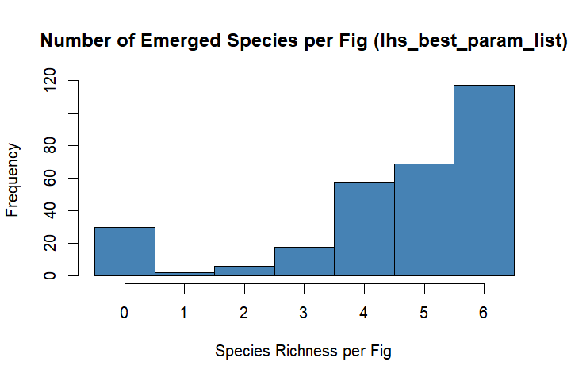

```
#> $stats_table
#>               Species Entry_Mean  Eggs_Mean Emergence_Mean
#> 1  Sycophaga_testacea   3.890000  52.626667       36.99000
#> 2        Apocrypta_sp  13.333333  12.913333       11.30000
#> 3     Sycophaga_mayri   5.236667  52.063333       33.81333
#> 4      Ceratosolen_sp   8.150000 469.590000      397.60667
#> 5 Sycophaga_agraensis   9.253333   8.133333        7.28000
#> 6 Apocrypta_westwoodi   9.170000  14.880000       13.74333
#>
#> $drop_summary
#>
#>   0   1
#> 272  28
#>
#> $richness_vector
#>   [1] 6 4 6 6 4 5 6 0 6 6 4 6 5 6 6 6 5 6 4 3 4 0 6 6 4 5 4 6 5 6 6 2 5 4 6 6 6
#>  [38] 4 5 6 6 5 6 2 0 5 5 4 0 2 6 5 6 6 5 6 6 0 6 5 6 5 6 5 6 6 3 6 4 4 5 6 1 6
#>  [75] 6 6 2 4 0 3 4 6 5 5 0 1 4 4 5 0 4 4 6 5 6 0 6 0 4 3 6 5 5 5 0 5 3 4 6 6 5
#> [112] 6 6 0 4 6 6 6 4 4 4 5 6 6 0 0 6 4 6 5 4 3 5 6 5 0 5 4 4 3 6 3 0 5 4 4 4 3
#> [149] 4 0 6 0 6 3 4 4 6 4 6 4 0 0 5 6 6 5 5 6 6 6 5 2 5 5 4 6 5 6 4 5 5 5 3 0 5
#> [186] 6 6 6 6 5 6 4 5 0 4 6 4 6 5 5 6 4 6 5 6 6 6 6 5 5 6 6 6 6 6 6 4 5 6 4 6 3
#> [223] 5 0 5 6 4 5 5 5 6 5 0 6 3 6 3 6 5 5 0 4 6 6 0 6 4 6 3 4 5 4 0 4 4 6 6 5 5
#> [260] 0 4 5 6 4 6 3 3 6 6 6 6 5 4 6 5 5 5 4 2 6 6 6 6 3 6 5 6 4 5 6 4 6 0 6 6 5
#> [297] 6 6 4 0
#>
#> $species_by_richness
#> # A tibble: 42 × 5
#>    richness Species             N_present Total_figs Proportion
#>       <dbl> <chr>                   <int>      <int>      <dbl>
#>  1        0 Apocrypta_sp                0         30        0
#>  2        0 Apocrypta_westwoodi         0         30        0
#>  3        0 Ceratosolen_sp              0         30        0
#>  4        0 Sycophaga_agraensis         0         30        0
#>  5        0 Sycophaga_mayri             0         30        0
#>  6        0 Sycophaga_testacea          0         30        0
#>  7        1 Apocrypta_sp                0          2        0
#>  8        1 Apocrypta_westwoodi         1          2        0.5
#>  9        1 Ceratosolen_sp              1          2        0.5
#> 10        1 Sycophaga_agraensis         0          2        0
#> # ℹ 32 more rows
#>
#> $heatmap
```

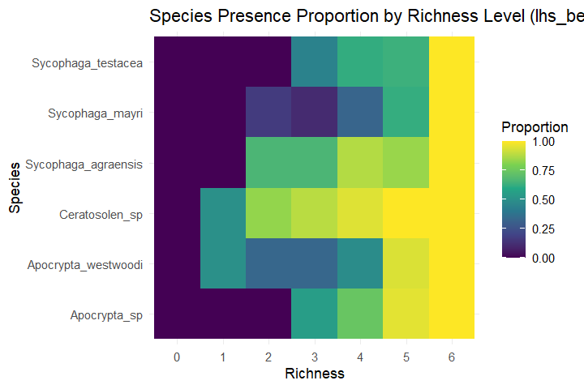

```r
# let plot it
summarize_simulated_metrics(sim_df, species_list, version_label = "lhs_best_param_list")
```

# 4. Act II — Quantify the model–data residual variance (‘Variation Gap’)

We compare Observed vs Simulated by resampling simulated figs to the same sample size and computing identical metrics.

```r
sim_metrics <- resample_simulated_metrics(
  n_draws   = if (RUN_HEAVY) 500 else 50,
  sample_n  = if (RUN_HEAVY) 200 else 100,
  num_figs  = nrow(sim_df),
  simulator_func = function(...) list(summary = sim_df),  # reuse existing sim
  calc_func = calc_all_metrics,
  wasp_cols = paste0("emergence_", species_list)
)

# Combine tags and run ordination/dispersion tests (example using NMDS + betadisper)
obs_tag <- observed_data
sim_tag <- sim_df[, paste0("emergence_", species_list), drop = FALSE]

obs_tag$group <- "Observed"
sim_tag$group <- "Simulated"

# Ensure column names match for rbind
colnames(sim_tag) <- gsub("^emergence_", "", colnames(sim_tag))

combined <- rbind(obs_tag, sim_tag)

combined <- combined[rowSums(combined[ , species_list]) > 0, ]
sp_mat   <- vegan::decostand(combined[ , species_list], method = "hellinger")
nmds     <- vegan::metaMDS(sp_mat, distance = "euclidean", k = 2, trymax = 10)
```

```
#> *** Best solution was not repeated -- monoMDS stopping criteria:
#>     10: scale factor of the gradient < sfgrmin
```

```r
# Dispersion comparison
dist_eu  <- vegan::vegdist(sp_mat, "euclidean")
bd       <- vegan::betadisper(dist_eu, group = factor(combined$group))
bd_perm  <- vegan::permutest(bd, permutations = 499)

bd_perm
```

```
#>
#> Permutation test for homogeneity of multivariate dispersions
#> Permutation: free
#> Number of permutations: 499
#>
#> Response: Distances
#>             Df Sum Sq Mean Sq      F N.Perm Pr(>F)
#> Groups       1  6.071  6.0706 78.439    499  0.002 **
#> Residuals 1197 92.639  0.0774
#> ---
#> Signif. codes:  0 '***' 0.001 '**' 0.01 '*' 0.05 '.' 0.1 ' ' 1
```

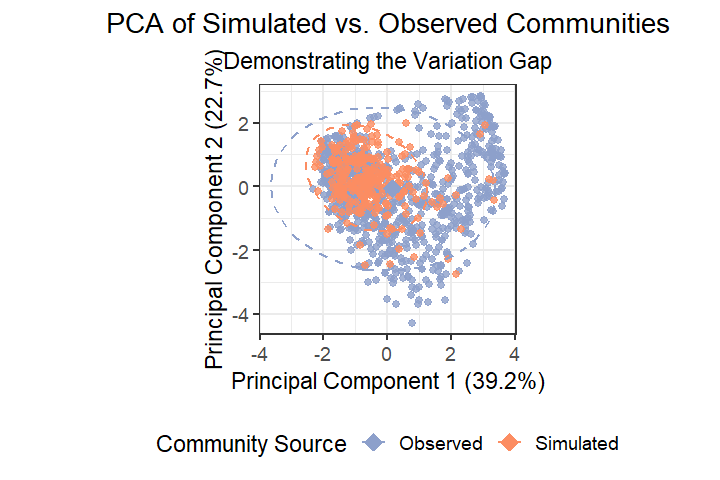

```r
pca <- stats::prcomp(sp_mat, scale. = TRUE)
plot_data <- as.data.frame(pca$x[, 1:2])
plot_data$group <- combined$group


pca_summary <- summary(pca)
variance_explained <- pca_summary$importance[2, 1:2] * 100

# --- PCA ---

centroids <- aggregate(cbind(PC1, PC2) ~ group, data = plot_data, FUN = mean)

ggplot(plot_data, aes(x = PC1, y = PC2, color = group)) +
  geom_point(alpha = 0.8, size = 2) +
  stat_ellipse(aes(group = group), type = "t", level = 0.95, linetype = "dashed", linewidth = 0.6) +
  geom_point(data = centroids, aes(x = PC1, y = PC2), size = 5, shape = 18) +
  scale_color_manual(values = c("Observed" = "#8da0cb", "Simulated" = "#fc8d62"),
                     name = "Community Source") +
  labs(title = "PCA of Simulated vs. Observed Communities",
       subtitle = "Demonstrating the Variation Gap",
       x = paste0("Principal Component 1 (", round(variance_explained[1], 1), "%)"),
       y = paste0("Principal Component 2 (", round(variance_explained[2], 1), "%)")) +
  theme_bw(base_size = 14) +
  theme(legend.position = "bottom",
        plot.title = element_text(hjust = 0.5),
        plot.subtitle = element_text(hjust = 0.5)) +
  coord_fixed()
```

**Interpretation.** If the simulated cloud matches means but exhibits smaller multivariate dispersion than observed, the Variation Gap is present (intrinsic model underestimates real variability). This result diagnoses a limit of the present model, not of ecological theory writ large. The magnitude and even the presence of the gap are model-, metric-, and dataset-dependent (e.g., choice of distance, sample size, site heterogeneity). As additional, well-supported processes are incorporated, the gap is expected to shrink.

# 5. Act III — Dissect internal mechanisms (knockouts)

We switch off individual modules (e.g., spatial layering, host sanctions) to quantify each mechanism’s contribution relative to the FIM. We set drop_cancels_emergence = FALSE to retain auditability (dropped figs keep their raw emergence counts). For analysis, we apply a masking policy on a copy of the data (set emergence to 0 for dropped figs), keeping the raw outputs intact.

```r
# module control options, more details: ?simulate_figwasp_community()
# use_layering = TRUE/FALSE
# use_layer_preference = TRUE/FALSE
# enable_drop = TRUE/FALSE
# drop_cancels_emergence = TRUE/FALSE
# use_supplemental_parasitism = TRUE/FALSE
# use_flower_limit = TRUE/FALSE
# use_egg_success_by_phase = TRUE/FALSE

# Example: remove spatial layering
sim_no_space <- simulate_figwasp_community(
  num_figs = if (RUN_HEAVY) 1000 else 300,
  fecundity_mean       = best_params$fecundity_mean,
  fecundity_dispersion = best_params$fecundity_dispersion,
  entry_mu             = best_params$entry_mu,
  entry_size           = best_params$entry_size,
  entry_priority       = best_params$entry_priority,
  species_roles        = best_params$species_roles,
  max_entry_table      = best_params$max_entry_table,
  enable_drop          = TRUE,
  drop_cancels_emergence = FALSE,
  entry_distribution   = "lognormal",
  interaction_matrix   = best_params$interaction_matrix,
  interaction_weight   = 0,
  egg_success_prob     = best_params$egg_success_prob,
  egg_success_prob_by_phase = best_params$egg_success_prob_by_phase,
  layer_preference     = best_params$layer_preference,
  use_layering         = FALSE,  # KO here
  seed                 = 43
)$summary

# Summarize metrics for FIM vs. KO
fim_metrics  <- resample_metrics_from_simulation(sim_df,       n_reps = 50, sample_size = 100, seed = 1)
ko_space   <- resample_metrics_from_simulation(sim_no_space, n_reps = 50, sample_size = 100, seed = 1)

# Loss vs empirical means (smaller = better to observed)
obs_means_row <- as.data.frame(t(colMeans(obs_metrics[ , setdiff(names(obs_metrics), "source") ], na.rm = TRUE)))
fim_loss      <- calculate_metric_loss(fim_metrics, obs_means_row)
ko_space_loss       <- calculate_metric_loss(ko_space,  obs_means_row)

list(FIM_total_loss = fim_loss$total_loss,
     KO_no_space_total_loss = ko_space_loss$total_loss)
```

```
#> $FIM_total_loss
#> [1] 8.9891
#>
#> $KO_no_space_total_loss
#> [1] 34.6743
```

```r
# Example: stop use phase-specific success probabilities
sim_no_prob_by_phase <- simulate_figwasp_community(
  num_figs = if (RUN_HEAVY) 1000 else 300,
  fecundity_mean       = best_params$fecundity_mean,
  fecundity_dispersion = best_params$fecundity_dispersion,
  entry_mu             = best_params$entry_mu,
  entry_size           = best_params$entry_size,
  entry_priority       = best_params$entry_priority,
  species_roles        = best_params$species_roles,
  max_entry_table      = best_params$max_entry_table,
  enable_drop          = TRUE,
  drop_cancels_emergence = FALSE,
  entry_distribution   = "lognormal",
  interaction_matrix   = best_params$interaction_matrix,
  interaction_weight   = 0,
  egg_success_prob     = best_params$egg_success_prob,
  egg_success_prob_by_phase = NULL, # turn it off
  use_egg_success_by_phase = FALSE, # turn it off
  layer_preference     = best_params$layer_preference,
  use_layering         = TRUE,
  seed                 = 43
)$summary

# Summarize metrics for KO prob_by_phase
ko_prob_by_phase   <- resample_metrics_from_simulation(sim_no_prob_by_phase, n_reps = 50, sample_size = 100, seed = 1)

# Loss vs empirical means (smaller = better to observed)
ko_prob_by_phase_loss <- calculate_metric_loss(ko_prob_by_phase,  obs_means_row)

list(FIM_total_loss = fim_loss$total_loss,
     KO_no_space_total_loss = ko_space_loss$total_loss,
     KO_prob_by_phase_total_loss = ko_prob_by_phase_loss$total_loss)
```

```
#> $FIM_total_loss
#> [1] 8.9891
#>
#> $KO_no_space_total_loss
#> [1] 34.6743
#>
#> $KO_prob_by_phase_total_loss
#> [1] 13.1083
```

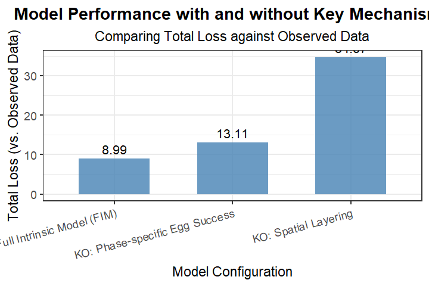

```r
knockout_results <- data.frame(
  mechanism = c(
    "Full Intrinsic Model (FIM)",
    "KO: Spatial Layering",
    "KO: Phase-specific Egg Success"
  ),
  total_loss = c(
    fim_loss$total_loss,
    ko_space_loss$total_loss,
    ko_prob_by_phase_loss$total_loss
  )
)


ggplot(knockout_results, aes(x = reorder(mechanism, total_loss), y = total_loss)) +
  geom_col(fill = "#4682B4", alpha = 0.8, width = 0.6) +
  geom_text(aes(label = round(total_loss, 2)), vjust = -0.5, size = 4.5) +
  labs(
    title = "Model Performance with and without Key Mechanisms",
    subtitle = "Comparing Total Loss against Observed Data",
    x = "Model Configuration",
    y = "Total Loss (vs. Observed Data)"
  ) +
  theme_bw(base_size = 14) +
  theme(
    plot.title = element_text(hjust = 0.5, face = "bold"),
    plot.subtitle = element_text(hjust = 0.5),
    axis.text.x = element_text(angle = 15, hjust = 1)
  )
```

# 6. Act IV — Probing the Host Sanction Threshold

Example — Host-sanction threshold (extreme setting). Here we illustrate an extreme host-sanction setting. We set the host-sanction threshold to 10% of a fig’s total flowers. If the number of ovules occupied by eggs of ovule-occupying guilds (pollinators + gallers) exceeds 10% of the fig’s flower count, the fig drops. When a fig drops, no fig wasps emerge. This example is for demonstration only; in practice, the threshold should be calibrated to empirical biology.

Notes: (i) Parasitoid eggs are not counted toward the ovule-occupation total because they do not occupy ovules directly. (ii) If your function still uses the legacy argument name host_sanction, use it; otherwise use the corrected host_sanction_threshold.

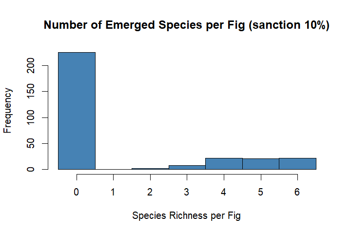

```
#>
#>   0   1
#>  75 225

summarize_simulated_metrics(sim_sanction_10, species_list, version_label = "sanction 10%")$stats_table
#>               Species Entry_Mean  Eggs_Mean Emergence_Mean
#> 1  Sycophaga_testacea   3.726667  53.250000       7.190000
#> 2        Apocrypta_sp  13.680000  12.966667       2.763333
#> 3     Sycophaga_mayri   5.026667  52.910000       7.880000
#> 4      Ceratosolen_sp   8.136667 459.236667      71.143333
#> 5 Sycophaga_agraensis   9.290000   8.216667       2.013333
#> 6 Apocrypta_westwoodi   9.336667  19.006667       4.513333
```

```r
# First, ensure the sanction mechanism *enable_sanctions <- TRUE *
# Run the simulation with this specific sanction rule
# Key change: set a strict host-sanction threshold at 10% of total flowers
# If ovule-occupying eggs (pollinators + gallers) > 10% of flowers -> fig drops -> zero emergence.
# We mark figs as dropped but keep eggs/emergence for inspection (drop_cancels_emergence = FALSE).
# For analysis, we create a masked copy where dropped figs' emergence counts are zeroed.

sim_sanction_10 <- simulate_figwasp_community(
  num_figs = if (RUN_HEAVY) 1000 else 300,
  fecundity_mean       = best_params$fecundity_mean,
  fecundity_dispersion = best_params$fecundity_dispersion,
  entry_mu             = best_params$entry_mu,
  entry_size           = best_params$entry_size,
  entry_priority       = best_params$entry_priority,
  species_roles        = best_params$species_roles,
  max_entry_table      = best_params$max_entry_table,
  enable_drop          = TRUE,
  drop_cancels_emergence = FALSE, # keep it as FALSE: it means "drop => zero emergence"
  entry_distribution   = "lognormal",
  interaction_matrix   = best_params$interaction_matrix,
  interaction_weight   = 0,
  host_sanction = 0.1, # the key change, default = 0.8
  egg_success_prob     = best_params$egg_success_prob,
  egg_success_prob_by_phase = best_params$egg_success_prob_by_phase,
  layer_preference     = best_params$layer_preference,
  use_layering         = TRUE,  # let's turn it on
  seed                 = 43
)

sim_sanction_10 <- sim_sanction_10$summary

# Quick check: how many figs dropped, and confirm dropped figs have zero emergence
summarize_simulated_metrics(sim_sanction_10, species_list, version_label = "sanction 10%")$drop_summary
```

**Interpretation.** The bigger the loss jump when a module is removed, the more important that module is for reproducing community structure within the intrinsic envelope. We use ‘intrinsic envelope’ purely as a modeling term; it does not imply other processes are stochastic by nature—only that they are not yet modeled here.

# 7. Practical notes for users

- **Speed vs. rigor.** The vignette runs with small `n_draws`, `sample_n`, and `n_samples`. For real analyses, increase these substantially.
- **Reproducibility.** Use `set.seed()` everywhere. If you enable parallelism, document RNG streams.
- **Progress bars.** `progressr::handlers()` may conflict with test runners—keep them off by default in vignettes.
- **Precomputed objects.** For long workflows, ship `.rds` and load them when available (as shown above).
- **Metric sensitivity.** Gap estimates depend on the dispersion metric (e.g., Bray–Curtis vs. Jaccard) and resampling scheme. Report effect sizes with uncertainty and perform sensitivity analyses.
- **Extensibility.** Treat the FIM vignette as a baseline. If a project requires environmental or spatial structure, add those modules and re-estimate the gap.